# HAR predictive project

Enrico Stanga

10/10/2022

## Purpose of the analysis

This analysis consists in the estimation of a ML model to predict the variable "classe" from the Weight Lifting Exercise Dataset.

## Import Libraries

```r
library(ggplot2)
library(caret)
library(kernlab)
library(randomForest)
```

## Loading Data

```r
setwd("C:\\Users\\e41570\\PycharmProjects\\ML_coursera_project\\input")
training = read.csv("pml-training.csv")
testing = read.csv("pml-testing.csv")
set.seed(41570)
ncol(training)
```

```
## [1] 160
```

The data presents some inconsistencies, like NAs, blanks and not relevant variables that has to be adjusted.

## PreProcessing

Reduce sparse variables removing columns with >95% of NAs or "":

```r
training[training==""] = NA
training = training[ , colSums(is.na(training)) < 0.95*nrow(training)]
ncol(training)
```

```
## [1] 60
```

Removing not relevant variables or not helpful for predictions, like windows, names and timestamps:

```r
training = training[, !(colnames(training) %in%
                              c("X","user_name","raw_timestamp_part_1",
                                "raw_timestamp_part_2","cvtd_timestamp",
                                "new_window","num_window"))]
ncol(training)
```

```
## [1] 53
```

## Data Splitting

The split performed for cross validation is: training set 70% and test set 30%.

```r
inTrain = createDataPartition(training$classe, p=0.7, list=FALSE)
train_set = training[inTrain,]
test_set = training[-inTrain,]
```

## Dimensionality Reduction

Reducing the number of predictors to reduce bias and prevent overfitting through the random forest algorithm.

```r
modFit = randomForest(as.factor(classe) ~ .,data=train_set)
print(modFit)
```

```
##
## Call:
##  randomForest(formula = as.factor(classe) ~ ., data = train_set)
##                Type of random forest: classification
##                      Number of trees: 500
## No. of variables tried at each split: 7
##
##         OOB estimate of  error rate: 0.52%
## Confusion matrix:
##      A    B    C    D    E class.error
## A 3902    4    0    0    0 0.001024066
## B   14 2639    5    0    0 0.007148232
## C    0   13 2380    3    0 0.006677796
## D    0    0   18 2232    2 0.008880995
## E    0    0    3   10 2512 0.005148515
```

```r
imp = varImp(modFit)
summary(imp)
```

```
##     Overall
##  Min.   : 40.36
##  1st Qu.: 91.11
##  Median :171.34
##  Mean   :208.86
##  3rd Qu.:238.19
##  Max.   :871.25
```

```r
reduced_set = names(train_set[, imp>240.81])
red_train_set = train_set[,names(train_set) %in% reduced_set]
red_test_set = test_set[,names(test_set) %in% reduced_set]
ncol(red_train_set)
```

```
## [1] 14
```

## Model Selection

```r
modFit_rf = train(classe ~., method="rf", data=red_train_set)
modFit_gbm = train(classe ~., method="gbm", data=red_train_set, verbose=FALSE)
```

## Prediction

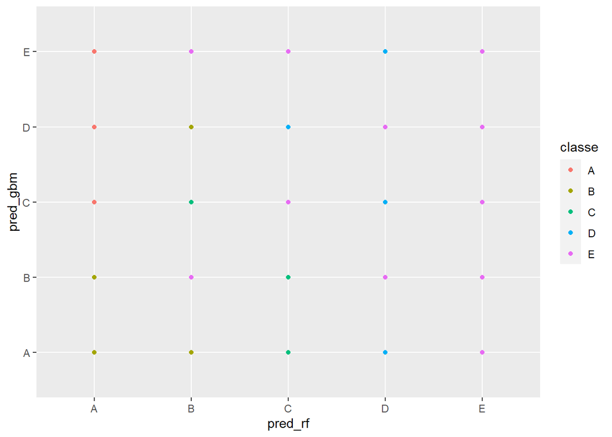

```r
pred_rf = predict(modFit_rf, red_test_set)
pred_gbm = predict(modFit_gbm, red_test_set)
qplot(pred_rf, pred_gbm, colour=classe, data=red_test_set)
```

Then I fit a model based on the combination of the predictors fitted with a random forest algorithm:

```r
preDF = data.frame(pred_rf, pred_gbm, classe=red_test_set$classe)
combModFit = train(classe ~., method="rf", data=preDF)
combPred = predict(combModFit, preDF)
```

## Confusion Matrices

```r
c1 = confusionMatrix(pred_rf, as.factor(red_test_set$classe))
c2 = confusionMatrix(pred_gbm, as.factor(red_test_set$classe))
c3 = confusionMatrix(combPred, as.factor(red_test_set$classe))

c1$table; c1$overall
```

```
##           Reference
## Prediction    A    B    C    D    E
##          A 1661   13    0    0    0
##          B   10 1104   12    0    3
##          C    2   16  997   10    3
##          D    1    6   17  949    7
##          E    0    0    0    5 1069
```

```
##       Accuracy          Kappa  AccuracyLower  AccuracyUpper   AccuracyNull
##      0.9821580      0.9774344      0.9784419      0.9853844      0.2844520
## AccuracyPValue  McnemarPValue
##      0.0000000            NaN
```

```r
c2$table; c2$overall
```

```
##           Reference
## Prediction    A    B    C    D    E
##          A 1619   35    3    2    2
##          B   37 1030   47    5   14
##          C    9   52  937   32   11
##          D    4   16   35  918   21
##          E    5    6    4    7 1034
```

```
##       Accuracy          Kappa  AccuracyLower  AccuracyUpper   AccuracyNull
##     0.94103653     0.92545289     0.93471140     0.94691990     0.28445200
## AccuracyPValue  McnemarPValue
##     0.00000000     0.00610702
```

```r
c3$table; c3$overall
```

```
##           Reference
## Prediction    A    B    C    D    E
##          A 1661   13    0    0    0
##          B   10 1104   12    0    3
##          C    2   16  997   10    3
##          D    1    6   17  949    7
##          E    0    0    0    5 1069
```

```
##       Accuracy          Kappa  AccuracyLower  AccuracyUpper   AccuracyNull
##      0.9821580      0.9774344      0.9784419      0.9853844      0.2844520
## AccuracyPValue  McnemarPValue
##      0.0000000            NaN
```

The most parsimonious model with the best accuracy is the first model estimated (Random Forest): 0.9821.

## Predicting on the test sample

```r
predict(modFit_rf,testing)
```

```
##  [1] B A B A A E D B A A B C B A E E A B B B
## Levels: A B C D E
```